# Sahadeo_Assignment10_BabySample

Rishi Sahadeo

2025-11-05

1. Treating the variable Preemie as the response variable, and MomAge as the explanatory variable, graphically display the data in an appropriate plot.

```r
set.seed(1347)

# load data
baby <- read.delim("babysamp-98_raw-datafile-1.txt", header = TRUE, sep = "\t", skip = 14, na.strings = c("NA", ""))

# display data
head(baby)
```

```
##   MomAge DadAge MomEduc MomMarital numlive dobmm gestation sex weight
## 1     14     NA       8          2       0    10        38   F   2977
## 2     15     20      NA          2       0     5        44   F   3459
## 3     15     NA       8          2       0     7        38   F   2892
## 4     15     NA       8          2       0     2        36   F   2552
## 5     16     NA       8          2       0     7        39   M   1985
## 6     16     NA      NA          2       0    11        23   F   1049
##   prenatalstart orig.id preemie
## 1             6 1123508   FALSE
## 2             5 1316782   FALSE
## 3             1  945363   FALSE
## 4             5 3145461    TRUE
## 5             2 1247735   FALSE
## 6             2 1578022    TRUE
```

```r
str(baby)
```

```
## 'data.frame':    200 obs. of  12 variables:
##  $ MomAge       : int  14 15 15 15 16 16 17 17 17 18 ...
##  $ DadAge       : int  NA 20 NA NA NA NA 22 NA 18 29 ...
##  $ MomEduc      : int  8 NA 8 8 8 NA 11 10 NA 10 ...
##  $ MomMarital   : int  2 2 2 2 2 2 1 2 1 1 ...
##  $ numlive      : int  0 0 0 0 0 0 0 0 0 0 ...
##  $ dobmm        : int  10 5 7 2 7 11 12 11 7 2 ...
##  $ gestation    : int  38 44 38 36 39 23 41 37 34 40 ...
##  $ sex          : chr  "F" "F" "F" "F" ...
##  $ weight       : int  2977 3459 2892 2552 1985 1049 3572 3005 3131 3285 ...
##  $ prenatalstart: int  6 5 1 5 2 2 2 2 3 3 ...
##  $ orig.id      : int  1123508 1316782 945363 3145461 1247735 1578022 2089823 3601417 3474067 1499305 ...
##  $ preemie      : logi  FALSE FALSE FALSE TRUE FALSE TRUE ...
```

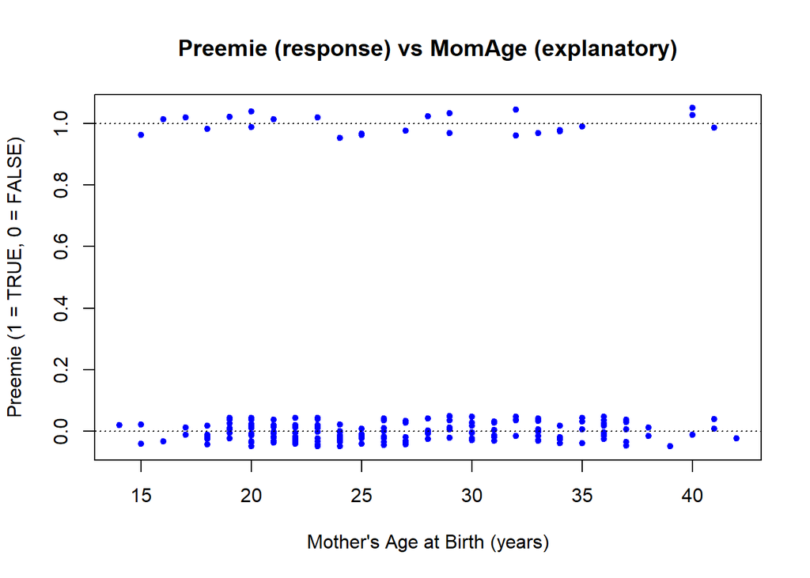

```r
# convert logical to 0/1
baby$preemie01 <- as.numeric(baby$preemie)

plot(
  x = baby$MomAge,
  y = jitter(baby$preemie01, amount = 0.05),
  xlab = "Mother's Age at Birth (years)",
  ylab = "Preemie (1 = TRUE, 0 = FALSE)",
  main = "Preemie (response) vs MomAge (explanatory)",
  pch = 19, cex = 0.7, col = "blue"
)
abline(h = c(0, 1), lty = 3, col = "black")
```

To visualize the relationship with the response on the vertical axis, I converted the binary variable preemie to 0/1 and created a jittered scatter plot with MomAge on the x-axis and preemie on the y-axis. The small vertical jitter prevents points from stacking at 0 and 1, making the distribution of the outcomes visible across maternal ages. Visually, most births are full-term (points near 0) across the age range, while preterm cases (points near 1) are fewer and appear scattered rather than showing a strong trend by age in this sample.

2. Among babies that were born prematurely, calculate the mean age of the mothers at birth Similarly, among the babies that were born full-term, calculate the mean age of the mothers at birth. Comment on the results.

```r
# counts by group
pre_n <- table(baby$preemie)

# means and sd by group
mu <- tapply(baby$MomAge, baby$preemie, mean, na.rm = TRUE)
sd <- tapply(baby$MomAge, baby$preemie, sd, na.rm = TRUE)

# summary
display <- data.frame(
  preemie = c(FALSE, TRUE),
  n = as.integer(pre_n[c("FALSE", "TRUE")]),
  mean_MomAge = as.numeric(mu[c("FALSE", "TRUE")]),
  sd_MomAge = as.numeric(sd[c("FALSE", "TRUE")])
)

display
```

```
##   preemie   n mean_MomAge sd_MomAge
## 1   FALSE 174    26.47701  6.292214
## 2    TRUE  26    27.30769  7.749938
```

Among 174 full term births, the mean maternal age was 26.5 years.

Among 26 premature births, the mean maternal age was 27.3 years.

A difference of +0.8 years. Mothers of premature babies were older on average in this sample. The small sample size of 26 preemies suggests caution in interpretation.

3. It is desired to model whether a baby is prematurely born using the mother’s birth age as an explanatory variable. Fit an appropriate model using the data provided and write out the formula for the model equation.

```r
# logical fit for preemie
fit <- glm(preemie ~ MomAge, data = baby, family = binomial(link = "logit"))
summary(fit)
```

```
##
## Call:
## glm(formula = preemie ~ MomAge, family = binomial(link = "logit"),
##     data = baby)
##
## Coefficients:
##             Estimate Std. Error z value Pr(>|z|)
## (Intercept) -2.42728    0.89767  -2.704  0.00685 **
## MomAge       0.01957    0.03209   0.610  0.54187
## ---
## Signif. codes:  0 '***' 0.001 '**' 0.01 '*' 0.05 '.' 0.1 ' ' 1
##
## (Dispersion parameter for binomial family taken to be 1)
##
##     Null deviance: 154.55  on 199  degrees of freedom
## Residual deviance: 154.19  on 198  degrees of freedom
## AIC: 158.19
##
## Number of Fisher Scoring iterations: 4
```

```r
# coefficients
coef(fit)
```

```
## (Intercept)      MomAge
## -2.42727806  0.01957339
```

```r
# odds ratio for a 1 year increase
exp(coef(fit)["MomAge"])
```

```
##   MomAge
## 1.019766
```

I fit a logistic regression model with preemie as the response and MomAge as the predictor using glm(). The fitted model is:

- logit p_hat = -2.4273 + 0.0196 * MomAge
4. Create another version of the plot created in part (1) displaying the same data with the graph of model equation arrived at in part (3) superimposed.

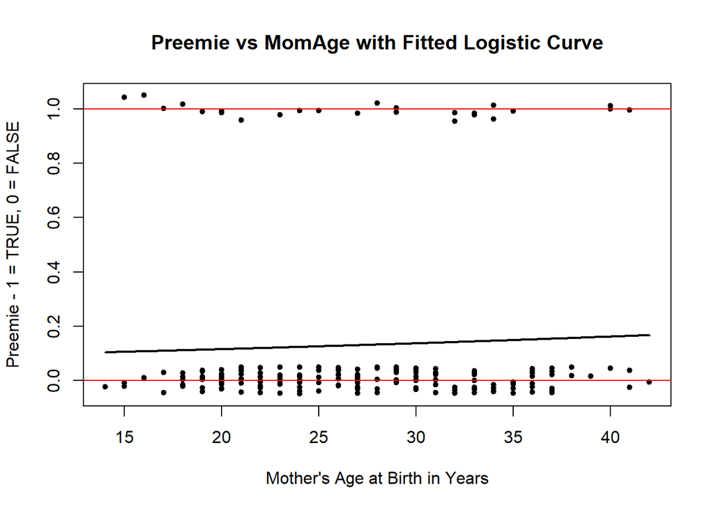

```r
# grid for ages and fitted probabilities for previous model
age_grid <- data.frame(MomAge = seq(min(baby$MomAge, na.rm = TRUE),
                                    max(baby$MomAge, na.rm = TRUE),
                                    length.out = 200))
p_hat <- predict(fit, newdata = age_grid, type = "response")

# redraw the jitter plot
plot(
  x = baby$MomAge,
  y = jitter(as.numeric(baby$preemie), amount = 0.05),
  xlab = "Mother's Age at Birth in Years",
  ylab = "Preemie - 1 = TRUE, 0 = FALSE",
  main = "Preemie vs MomAge with Fitted Logistic Curve",
  pch = 19, cex = 0.7, col = "black"
)
abline(h = c(0,1), lty = 7, col = "red")

# fitted logistic curve
lines(age_grid$MomAge, p_hat, lwd = 2)
```

I recreated the jittered 0/1 plot of preemie vs MomAge and superimposed the fitted logistic curve from Q3. The curve is the models predicted probability evaluated over the observed age range.

5. Is there a statistically significant association between the probability a baby is born prematurely and the mother’s birth age? Explain the methodology you used to arrive at your conclusion.

```r
# Wald (z) test
summary(fit)$coef
```

```
##                Estimate Std. Error   z value    Pr(>|z|)
## (Intercept) -2.42727806 0.89766860 -2.703980 0.006851439
## MomAge       0.01957339 0.03208847  0.609982 0.541873751
```

```r
# 95% Wald Ci for slope
b1 <- coef(fit)["MomAge"]
se1 <- summary(fit)$coef["MomAge", "Std. Error"]
wald_ci <- b1 + c(-1, 1) * 1.96 * se1
wald_ci
```

```
## [1] -0.04332001  0.08246679
```

```r
# likelihood-ratio test vs intercept only model
fit0 <- glm(preemie ~ 1, data = baby, family = binomial)
anova(fit0, fit, test = "Chisq")
```

```
## Analysis of Deviance Table
##
## Model 1: preemie ~ 1
## Model 2: preemie ~ MomAge
##   Resid. Df Resid. Dev Df Deviance Pr(>Chi)
## 1       199     154.56
## 2       198     154.19  1  0.36938   0.5433
```

To test whether prematurity is associated with mother’s age, I tested:

- H_0: Beta_1 = 0 in the logistic model logit(p) = Beta_0 + Beta_1(MomAge)

Using the fitted model, the Wald test gives:

- z = 0.610
- p = 0.542
- 95% CI for Beta_1 = (-0.0433, 0.0825), which includes 0.

A likelihood ratio test comparing the model with MomAge to an intercept-only model also yields p - 0.543.

Conclusion: At the 5% level, there is no statistically significant association between prematurity and mother’s age in this sample.

6. Create a version of the plot created in part (4) with bands superimposed that encompass with level of coverage 95% the ‘true’ probability a baby will be born prematurely for any given age.

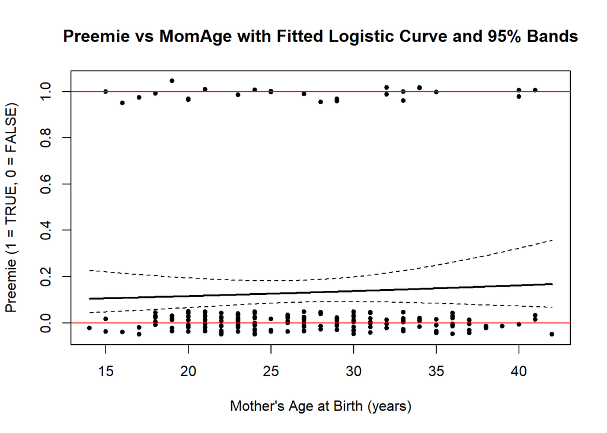

```r
# predict on logit to get SEs
pred <- predict(fit, newdata = age_grid, type = "link", se.fit = TRUE)

eta_hat <- pred$fit
se_eta <- pred$se.fit
crit <- qnorm(0.975)

# 95% CI on logit scale
lo_eta <- eta_hat - crit * se_eta
hi_eta <- eta_hat + crit * se_eta

# inverse-logit to probabilities
inv_logit <- function(z) 1/(1+exp(-z))
p_hat <- inv_logit(eta_hat)
p_lo <- inv_logit(lo_eta)
p_hi <- inv_logit(hi_eta)

# replot data
plot(
  x = baby$MomAge,
  y = jitter(as.numeric(baby$preemie), amount = 0.05),
  xlab = "Mother's Age at Birth (years)",
  ylab = "Preemie (1 = TRUE, 0 = FALSE)",
  main = "Preemie vs MomAge with Fitted Logistic Curve and 95% Bands",
  pch = 19, cex = 0.7, col = "black"
)
abline(h = c(0,1), lty = 7, col = "red")

# fitteed curve and CI boundaries
lines(age_grid$MomAge, p_hat, lwd = 2)
lines(age_grid$MomAge, p_lo, lwd = 1, lty = 2)
lines(age_grid$MomAge, p_hi, lwd = 1, lty = 2)
```

I constructed pointwise 95% confidence bands for the mean probability curve by forming eta_hat(x) +- 1.96SE on the logit scale from the GLM, then inverse-logit transforming to the probability scale. The wide, nearly horizontal bands reflect high uncertainty and no clear age effect.